# MEGALECTRICS 2021 SALES REPORT

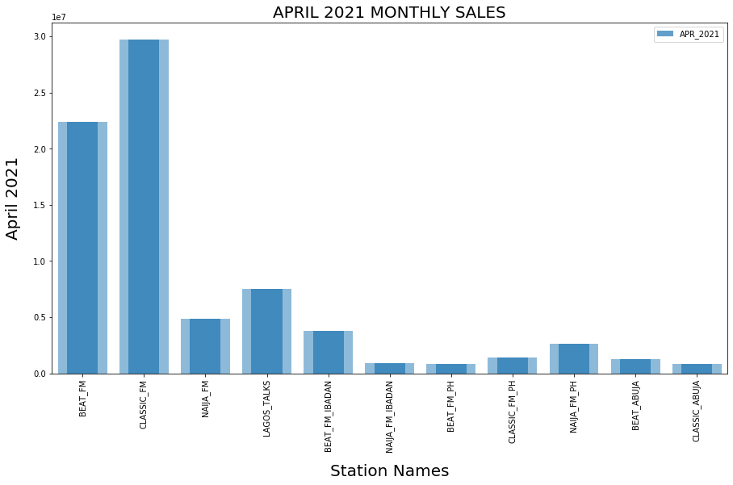

```python
sales2021.plot.bar(x="STATION_NAMES", y="APR_2021", figsize = (15,8), alpha = 0.7);
plt.bar(sales2021['STATION_NAMES'], sales2021['APR_2021'], alpha = 0.5);
plt.title('APRIL 2021 MONTHLY SALES', fontsize = 20);
plt.xlabel('Station Names', fontsize = 20, labelpad=15);
plt.ylabel('April 2021', fontsize = 20, labelpad=15);
```

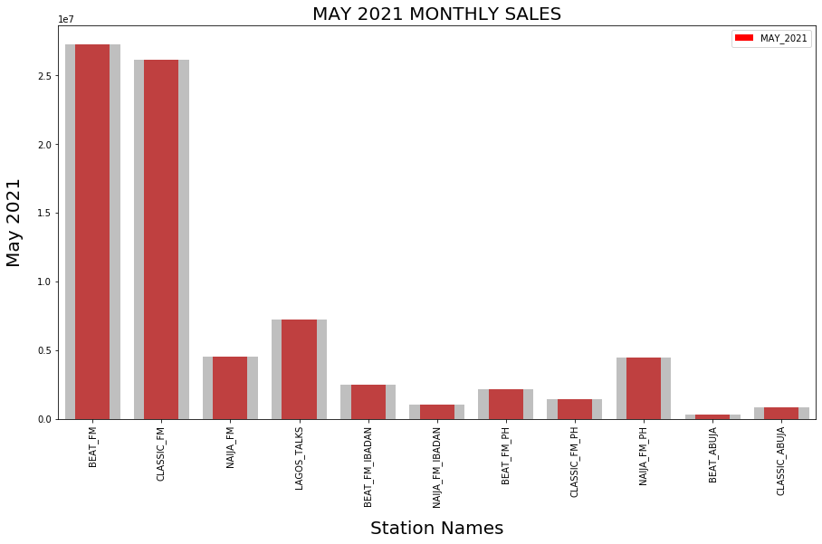

```python
sales2021.plot.bar(x="STATION_NAMES", y="MAY_2021", figsize = (15,8),  color = 'red');
plt.bar(sales2021['STATION_NAMES'], sales2021['MAY_2021'],color = 'gray', alpha = 0.5);
plt.title('MAY 2021 MONTHLY SALES', fontsize = 20);
plt.xlabel('Station Names', fontsize = 20, labelpad=15);

plt.ylabel('May 2021', fontsize = 20, labelpad=15);
```

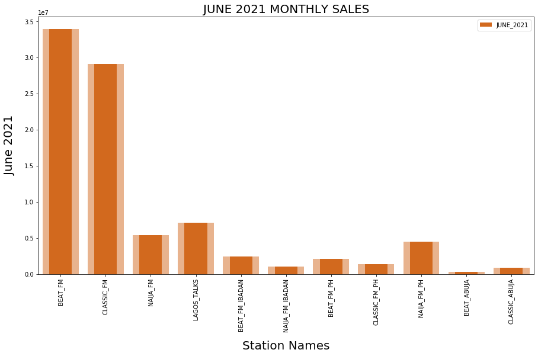

```python
sales2021.plot.bar(x="STATION_NAMES", y="JUNE_2021", figsize = (15,8), color = 'chocolate');
plt.bar(sales2021['STATION_NAMES'], sales2021['JUNE_2021'], color = 'chocolate', alpha = 0.5 );
plt.title('JUNE 2021 MONTHLY SALES', fontsize = 20);
plt.xlabel('Station Names', fontsize = 20, labelpad=15);
plt.ylabel('June 2021', fontsize = 20, labelpad=15);
```

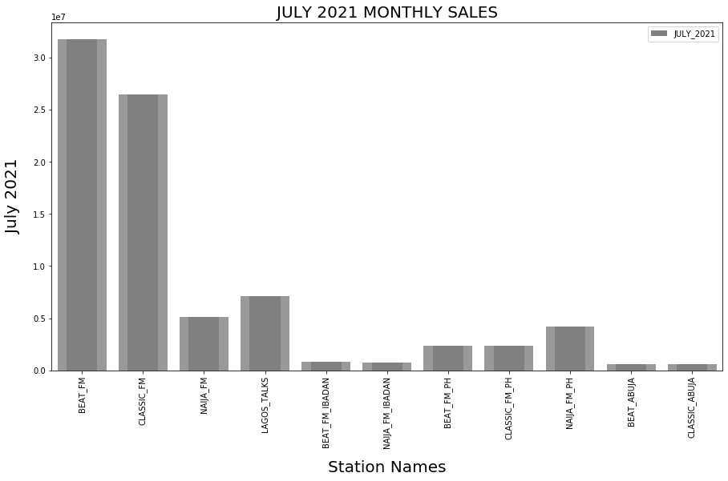

```python
sales2021.plot.bar(x="STATION_NAMES", y="JULY_2021", figsize = (15,8), color = 'grey');
plt.bar(sales2021['STATION_NAMES'], sales2021['JULY_2021'], color = 'grey', alpha = 0.8);
plt.title('JULY 2021 MONTHLY SALES', fontsize = 20);
plt.xlabel('Station Names', fontsize = 20, labelpad=15);
plt.ylabel('July 2021', fontsize = 20, labelpad=15);
```

## 2021 QUARTERLY SALES

> For Quarterly sales, we visualized each sale by 1st and 2nd quarter for each station across the board. Our observation was that out of all the stations across the board CLASSIC FM Lagos has been good so far for 1st and 2nd Quarters, followed by BEAT FM Lagos. The remaining stations have fairly sales throughout each quarter.

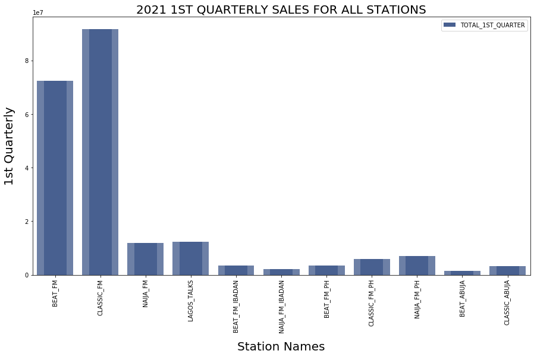

```python
sales2021.plot.bar(x="STATION_NAMES", y="TOTAL_1ST_QUARTER", figsize = (15,8), color = '#486090');
plt.bar(sales2021['STATION_NAMES'], sales2021['TOTAL_1ST_QUARTER'], color = '#486090', alpha = 0.8);
plt.title('2021 1ST QUARTERLY SALES FOR ALL STATIONS', fontsize = 20);
plt.xlabel('Station Names', fontsize = 20, labelpad=15);
plt.ylabel('1st Quarterly', fontsize = 20, labelpad=15);
```

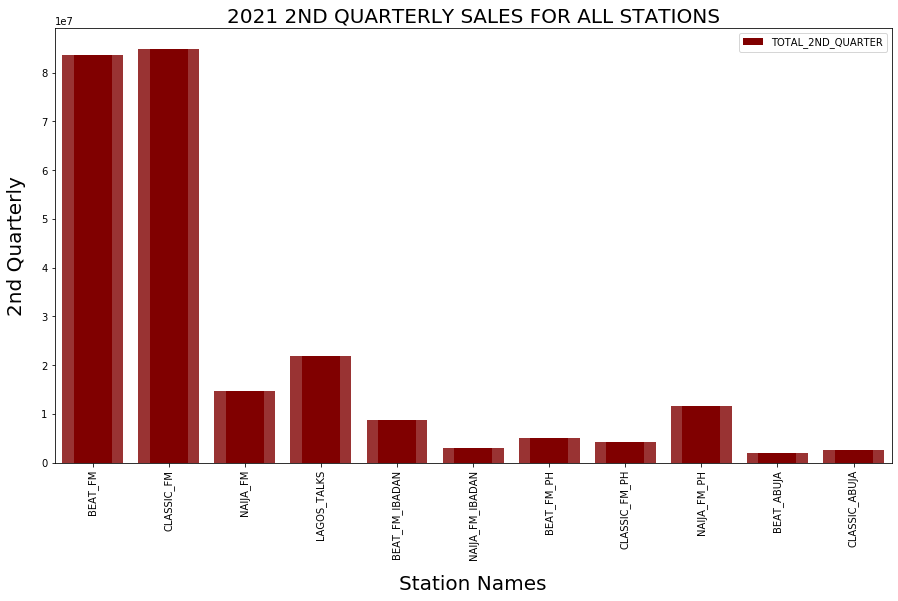

```python
sales2021.plot.bar(x="STATION_NAMES", y="TOTAL_2ND_QUARTER", figsize = (15,8), color = 'maroon');
plt.bar(sales2021['STATION_NAMES'], sales2021['TOTAL_2ND_QUARTER'], color = 'maroon', alpha = 0.8);
plt.title('2021 2ND QUARTERLY SALES FOR ALL STATIONS', fontsize = 20);
plt.xlabel('Station Names', fontsize = 20, labelpad=15);
plt.ylabel('2nd Quarterly', fontsize = 20, labelpad=15);
```